Non-Linear Methods · Splines · Polynomials

# Predicting Wage with *Non-Linear* Age Effects

Fitting natural splines and polynomial regression to model wage as a non-linear function of age, with tuned degrees of freedom and partial dependence visualization using the wage dataset.

Natural Splines Polynomial Regression 10-Fold CV PDP / DALEXtra Elastic Net

## Dataset Overview & Missing Data

The wage dataset (adapted from the ISLR package) contains 3,000 observations and 11 variables describing worker characteristics and wages in the mid-Atlantic region. The target variable is `wage` (weekly wage in thousands of dollars), and the analysis focuses on predicting it from `age`, `health_ins`, `jobclass`, `education`, and `race`.

```
library(visdat)
load("data/wage.rda")
vis_dat(wage)
vis_miss(wage)
```

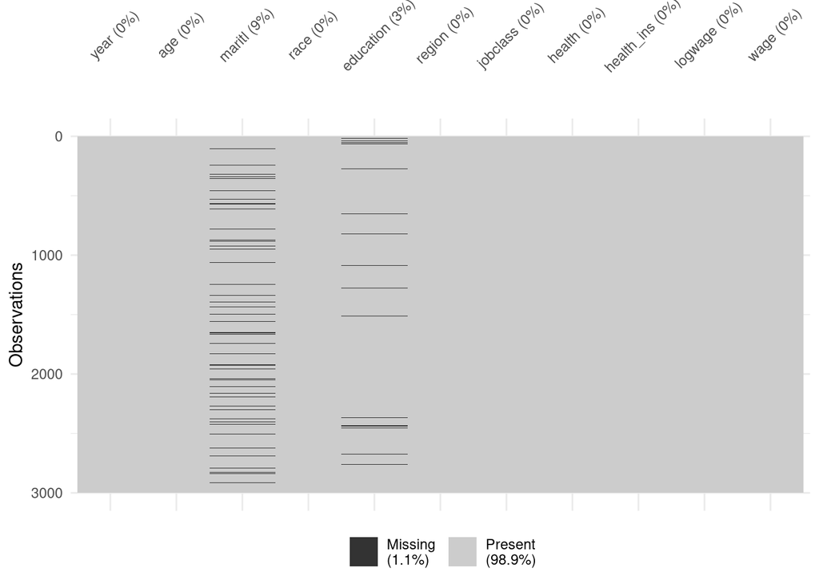

Figure 1. Missing data visualization for the wage dataset. The maritl variable has 264 missing values (~9%) and education has 88 (~3%); all other variables are complete.

colSums(is.na(wage)) year age maritl race education region jobclass health health_ins logwage wage 0 0 264 0 88 0 0 0 0 0 0

About 1.1% of total data is missing. The `maritl` column (9% missing) and `education` column (3% missing) are the affected predictors. Since the proportion of missing data is small, the preprocessing pipeline uses `step_naomit(all_predictors())` to remove incomplete cases—a practical choice that avoids introducing bias from imputation while losing very few observations.

## Wage Distribution

[figure not shown]

## Natural Splines for Age: Theory & Setup

Natural splines are piecewise polynomials joined at *knots*, constrained to be linear beyond the boundary knots. This makes them more stable than unconstrained polynomials at the extremes of the data. The **degrees of freedom** (df) parameter controls flexibility: a natural spline with df = k has k−1 internal knots placed at quantiles of the predictor.

**Example: df = 3** → 2 internal knots at the 33.3rd and 66.7th percentiles of age. For this dataset, the knots fall at **age = 37 and age = 48**.

Rather than pre-specifying the degrees of freedom, the optimal df was tuned using 10-fold cross-validation with `tune()`:

```
wage_recipe <- recipe(wage ~ age + health_ins + jobclass + education + race,
                      data = wage) |>
  step_naomit(all_predictors()) |>
  step_ns(age, deg_free = tune())

wf <- workflow() |>
  add_recipe(wage_recipe) |>
  add_model(linear_reg(engine = 'lm'))
```

```
grid <- data.frame(deg_free = 1:10)
set.seed(142)
wage_folds <- vfold_cv(wage, v = 10)

tuned_results <- tune_grid(wf, resamples = wage_folds, grid = grid)
show_best(tuned_results, metric = "rmse")
```

# A tibble: 5 × 7 deg_free .metric .estimator mean n std_err .config <int> <chr> <chr> <dbl> <int> <dbl> <chr> 1 6 rmse standard 34.5 10 0.855 Preprocessor06_Model1 2 5 rmse standard 34.5 10 0.851 Preprocessor05_Model1 3 8 rmse standard 34.5 10 0.840 Preprocessor08_Model1 4 3 rmse standard 34.5 10 0.852 Preprocessor03_Model1 5 7 rmse standard 34.5 10 0.853 Preprocessor07_Model1

The optimal degrees of freedom for the natural spline is **df = 6** (CV RMSE = 34.46). This means 5 internal knots are placed at evenly spaced quantiles of age.

## Partial Dependence Profile: Natural Spline

After fitting the finalized spline model on the full dataset, a Partial Dependence Plot (PDP) was generated using the DALEXtra package. The PDP shows the marginal effect of age on predicted wage, averaging over all other predictor values.

```
model_explainer <- explain_tidymodels(final_fit,
                                      data = wage,
                                      y = wage$wage,
                                      label = 'Linear Regression with Age Spline')

age_profile_pdp <- model_profile(model_explainer, variables = 'age')
ggplot_pdp(age_profile_pdp, age)
```

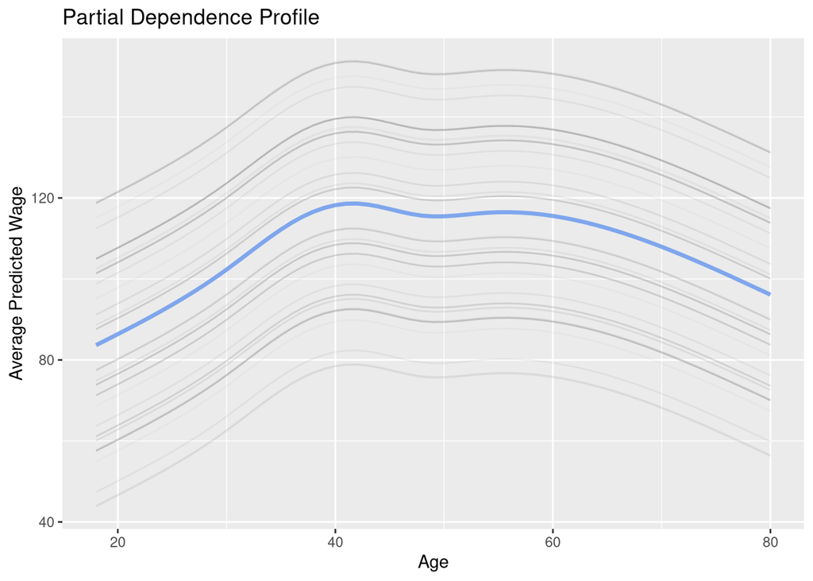

Figure 3. Partial dependence of predicted wage on age using the natural spline model (df = 6). The non-linear relationship is clearly captured.

The PDP reveals a **non-linear, inverted-U relationship** between age and wage: predicted wages rise steeply from early career (~age 18) through middle age (~age 40), plateau until approximately age 60, then gradually decline for older workers.

## Polynomial Regression for Age: Comparison

As an alternative to splines, a polynomial basis expansion of age was fit with degree tuned via cross-validation over degrees 1 through 10.

```
wage_recipe_poly <- recipe(wage ~ age + health_ins + jobclass + education + race,
                           data = wage) |>
  step_naomit(all_predictors()) |>
  step_poly(age, degree = tune())

tuned_poly_results <- tune_grid(wf_poly, resamples = wage_folds, grid = grid)
show_best(tuned_poly_results, metric = 'rmse')
```

# Best model: degree = 7, RMSE = 34.47

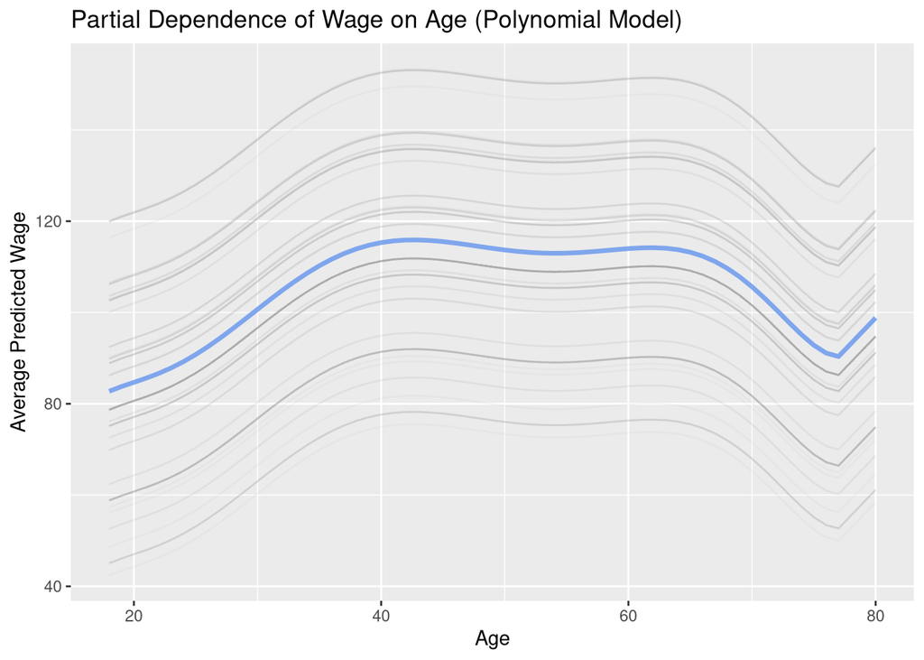

Figure 4. Partial dependence of predicted wage on age using the polynomial model (degree = 7). The overall shape is similar to the spline model but with sharper oscillations near the boundaries.

Natural Spline (df = 6)

CV RMSE: 34.46

Smooth, stable fit at boundaries

Linear extrapolation beyond knots prevents boundary oscillation

Polynomial (degree = 7)

CV RMSE: 34.47

Similar central fit, sharper boundary behavior

High-degree polynomials can produce Runge's phenomenon at extremes

The natural spline is preferred for prediction: its CV RMSE is marginally lower, and its boundary behavior is more stable. High-degree polynomials can exhibit Runge's phenomenon—extreme oscillations at the edges of the data range—which reduces generalization to new observations at unusual age values.

## Elastic Net with Natural Spline Features

Finally, the optimal natural spline features were combined with an elastic net penalty to test whether regularization could improve the spline model. A joint grid over penalty λ and mixture α was tuned via 10-fold CV.

```
wage_recipe_reg <- recipe(wage ~ age + health_ins + jobclass + education + race,
                          data = wage) |>
  step_naomit(all_predictors()) |>
  step_ns(age, deg_free = 6) |>
  step_dummy(all_nominal_predictors()) |>
  step_normalize(all_numeric_predictors())

grid <- expand_grid(penalty = seq(0, 3, by = 0.5),
                    mixture = seq(0, 1, by = 0.1))
```

[figure not shown]

# Best parameters: penalty = 0, mixture ≈ 0.9 → CV RMSE = 34.46 # As penalty increases, RMSE consistently rises across all α values.

### Summary & Conclusions

The partial dependence plots confirm the economic intuition: wages rise through early career, plateau in middle age, and decline in later years—a pattern that a simple linear model would completely miss.

The elastic net analysis further confirms that the spline model is already well-specified: regularization provides no additional benefit, suggesting the predictors are informative and the model is neither overfit nor underfit at the chosen flexibility.